# Risk Factor Analysis

## Outcome Variable

**Outcome Variable:** haz

## Predictor Variables

**Intervention Variable:** earlybf

**Adjustment Set:**

- arm
- sex
- W_mage
- meducyrs
- feducyrs
- hhwealth_quart
- hfoodsec
- W_mhtcm
- W_mwtkg
- W_mbmi
- vagbrth
- W_gagebrth
- W_birthwt
- W_birthlen
- W_nrooms
- W_nchldlt5
- brthmon
- W_parity
- impfloor
- impsan
- safeh20
- delta_W_mage
- delta_meducyrs
- delta_feducyrs
- delta_hhwealth_quart
- delta_hfoodsec
- delta_W_mhtcm
- delta_W_mwtkg
- delta_W_mbmi
- delta_vagbrth
- delta_W_gagebrth
- delta_W_birthwt
- delta_W_birthlen
- delta_W_nrooms
- delta_W_nchldlt5
- delta_brthmon
- delta_W_parity
- delta_impfloor
- delta_impsan
- delta_safeh20

## Stratifying Variables

The analysis was stratified on these variable(s):

- agecat
- studyid
- country

## Data Summary

| agecat | studyid | country | earlybf | n_cell | n | outcome_variable |
| --- | --- | --- | --- | --- | --- | --- |
| Birth | ki0047075b-MAL-ED | BANGLADESH | 1 | 147 | 230 | haz |
| Birth | ki0047075b-MAL-ED | BANGLADESH | 0 | 83 | 230 | haz |
| Birth | ki0047075b-MAL-ED | BRAZIL | 1 | 28 | 65 | haz |
| Birth | ki0047075b-MAL-ED | BRAZIL | 0 | 37 | 65 | haz |
| Birth | ki0047075b-MAL-ED | INDIA | 1 | 32 | 46 | haz |
| Birth | ki0047075b-MAL-ED | INDIA | 0 | 14 | 46 | haz |
| Birth | ki0047075b-MAL-ED | NEPAL | 1 | 14 | 27 | haz |
| Birth | ki0047075b-MAL-ED | NEPAL | 0 | 13 | 27 | haz |
| Birth | ki0047075b-MAL-ED | PERU | 1 | 175 | 233 | haz |
| Birth | ki0047075b-MAL-ED | PERU | 0 | 58 | 233 | haz |
| Birth | ki0047075b-MAL-ED | SOUTH AFRICA | 1 | 69 | 111 | haz |
| Birth | ki0047075b-MAL-ED | SOUTH AFRICA | 0 | 42 | 111 | haz |
| Birth | ki0047075b-MAL-ED | TANZANIA, UNITED REPUBLIC OF | 1 | 111 | 125 | haz |
| Birth | ki0047075b-MAL-ED | TANZANIA, UNITED REPUBLIC OF | 0 | 14 | 125 | haz |
| Birth | ki1000109-EE | PAKISTAN | 1 | 44 | 229 | haz |
| Birth | ki1000109-EE | PAKISTAN | 0 | 185 | 229 | haz |
| Birth | ki1000304b-SAS-CompFeed | INDIA | 1 | 86 | 1207 | haz |
| Birth | ki1000304b-SAS-CompFeed | INDIA | 0 | 1121 | 1207 | haz |
| Birth | ki1017093c-NIH-Crypto | BANGLADESH | 1 | 634 | 732 | haz |
| Birth | ki1017093c-NIH-Crypto | BANGLADESH | 0 | 98 | 732 | haz |
| Birth | ki1113344-GMS-Nepal | NEPAL | 1 | 180 | 632 | haz |
| Birth | ki1113344-GMS-Nepal | NEPAL | 0 | 452 | 632 | haz |
| Birth | ki1126311-ZVITAMBO | ZIMBABWE | 1 | 6556 | 12354 | haz |
| Birth | ki1126311-ZVITAMBO | ZIMBABWE | 0 | 5798 | 12354 | haz |
| Birth | kiGH5241-JiVitA-3 | BANGLADESH | 1 | 236 | 22370 | haz |
| Birth | kiGH5241-JiVitA-3 | BANGLADESH | 0 | 22134 | 22370 | haz |
| Birth | kiGH5241-JiVitA-4 | BANGLADESH | 1 | 1912 | 2823 | haz |
| Birth | kiGH5241-JiVitA-4 | BANGLADESH | 0 | 911 | 2823 | haz |
| 6 months | ki0047075b-MAL-ED | BANGLADESH | 1 | 147 | 240 | haz |
| 6 months | ki0047075b-MAL-ED | BANGLADESH | 0 | 93 | 240 | haz |

[output cut: 52 more lines]

The following strata were considered:

- agecat: 24 months, studyid: ki0047075b-MAL-ED, country: BANGLADESH
- agecat: 24 months, studyid: ki0047075b-MAL-ED, country: BRAZIL
- agecat: 24 months, studyid: ki0047075b-MAL-ED, country: INDIA
- agecat: 24 months, studyid: ki0047075b-MAL-ED, country: NEPAL
- agecat: 24 months, studyid: ki0047075b-MAL-ED, country: PERU
- agecat: 24 months, studyid: ki0047075b-MAL-ED, country: SOUTH AFRICA
- agecat: 24 months, studyid: ki0047075b-MAL-ED, country: TANZANIA, UNITED REPUBLIC OF
- agecat: 24 months, studyid: ki1000109-EE, country: PAKISTAN
- agecat: 24 months, studyid: ki1017093c-NIH-Crypto, country: BANGLADESH
- agecat: 24 months, studyid: ki1113344-GMS-Nepal, country: NEPAL
- agecat: 24 months, studyid: ki1126311-ZVITAMBO, country: ZIMBABWE
- agecat: 24 months, studyid: kiGH5241-JiVitA-3, country: BANGLADESH
- agecat: 24 months, studyid: kiGH5241-JiVitA-4, country: BANGLADESH
- agecat: 6 months, studyid: ki0047075b-MAL-ED, country: BANGLADESH
- agecat: 6 months, studyid: ki0047075b-MAL-ED, country: BRAZIL
- agecat: 6 months, studyid: ki0047075b-MAL-ED, country: INDIA
- agecat: 6 months, studyid: ki0047075b-MAL-ED, country: NEPAL
- agecat: 6 months, studyid: ki0047075b-MAL-ED, country: PERU
- agecat: 6 months, studyid: ki0047075b-MAL-ED, country: SOUTH AFRICA
- agecat: 6 months, studyid: ki0047075b-MAL-ED, country: TANZANIA, UNITED REPUBLIC OF
- agecat: 6 months, studyid: ki1000109-EE, country: PAKISTAN
- agecat: 6 months, studyid: ki1000304b-SAS-CompFeed, country: INDIA
- agecat: 6 months, studyid: ki1017093c-NIH-Crypto, country: BANGLADESH
- agecat: 6 months, studyid: ki1113344-GMS-Nepal, country: NEPAL
- agecat: 6 months, studyid: ki1126311-ZVITAMBO, country: ZIMBABWE
- agecat: 6 months, studyid: kiGH5241-JiVitA-3, country: BANGLADESH
- agecat: 6 months, studyid: kiGH5241-JiVitA-4, country: BANGLADESH
- agecat: Birth, studyid: ki0047075b-MAL-ED, country: BANGLADESH
- agecat: Birth, studyid: ki0047075b-MAL-ED, country: BRAZIL
- agecat: Birth, studyid: ki0047075b-MAL-ED, country: INDIA
- agecat: Birth, studyid: ki0047075b-MAL-ED, country: NEPAL
- agecat: Birth, studyid: ki0047075b-MAL-ED, country: PERU
- agecat: Birth, studyid: ki0047075b-MAL-ED, country: SOUTH AFRICA
- agecat: Birth, studyid: ki0047075b-MAL-ED, country: TANZANIA, UNITED REPUBLIC OF
- agecat: Birth, studyid: ki1000109-EE, country: PAKISTAN
- agecat: Birth, studyid: ki1000304b-SAS-CompFeed, country: INDIA
- agecat: Birth, studyid: ki1017093c-NIH-Crypto, country: BANGLADESH
- agecat: Birth, studyid: ki1113344-GMS-Nepal, country: NEPAL
- agecat: Birth, studyid: ki1126311-ZVITAMBO, country: ZIMBABWE
- agecat: Birth, studyid: kiGH5241-JiVitA-3, country: BANGLADESH
- agecat: Birth, studyid: kiGH5241-JiVitA-4, country: BANGLADESH

### Dropped Strata

Some strata were dropped due to rare outcomes:

- agecat: 24 months, studyid: kiGH5241-JiVitA-3, country: BANGLADESH

## Methods Detail

We’re interested in the causal parameters $E[Y_a]$ for all values of $a \in \mathcal{A}$. These parameters represent the mean outcome if, possibly contrary to fact, we intervened to set all units to have $A=a$. Under the randomization and positivity assumptions, these are identified by the statistical parameters $\psi_a=E_W[E_{Y|A,W}(Y|A=a,W)]$. In addition, we’re interested in the mean of $Y$, $E[Y]$ under no intervention (the observed mean). We will estimate these parameters by using SuperLearner to fit the relevant likelihood factors – $E_{Y|A,W}(Y|A=a,W)$ and $p(A=a|W)$, and then updating our likelihood fit using a joint TMLE.

For unadjusted analyses ($W=\{\}$), initial likelihoods were estimated using Lrnr_glm to estimate the simple $E(Y|A)$ and Lrnr_mean to estimate $p(A)$. For adjusted analyses, a small library containing Lrnr_glmnet, Lrnr_xgboost, and Lrnr_mean was used.

# Results Detail

## Results Plots

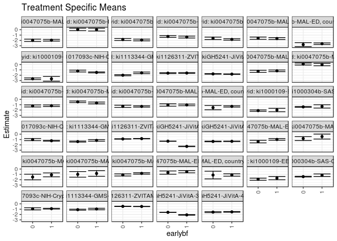

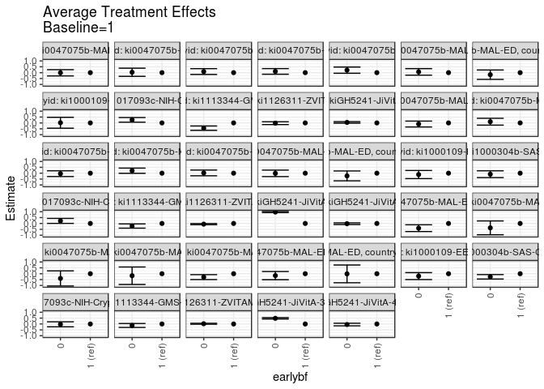

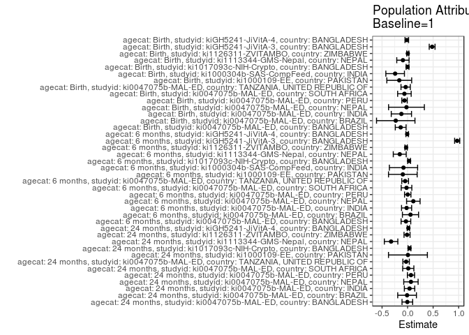

## Results Table

### Parameter: TSM

| agecat | studyid | country | intervention_level | baseline_level | estimate | ci_lower | ci_upper |
| --- | --- | --- | --- | --- | --- | --- | --- |
| Birth | ki0047075b-MAL-ED | BANGLADESH | 1 | NA | -0.9865281 | -1.1453284 | -0.8277279 |
| Birth | ki0047075b-MAL-ED | BANGLADESH | 0 | NA | -1.3861891 | -1.6256586 | -1.1467195 |
| Birth | ki0047075b-MAL-ED | BRAZIL | 1 | NA | -0.4440885 | -0.9057788 | 0.0176017 |
| Birth | ki0047075b-MAL-ED | BRAZIL | 0 | NA | -0.8175771 | -1.1780449 | -0.4571093 |
| Birth | ki0047075b-MAL-ED | INDIA | 1 | NA | -1.1006541 | -1.4672858 | -0.7340223 |
| Birth | ki0047075b-MAL-ED | INDIA | 0 | NA | -1.5021794 | -2.0309381 | -0.9734207 |
| Birth | ki0047075b-MAL-ED | NEPAL | 1 | NA | -0.8312515 | -1.3620994 | -0.3004036 |
| Birth | ki0047075b-MAL-ED | NEPAL | 0 | NA | -1.0008374 | -1.5234122 | -0.4782627 |
| Birth | ki0047075b-MAL-ED | PERU | 1 | NA | -0.8226353 | -0.9510558 | -0.6942147 |
| Birth | ki0047075b-MAL-ED | PERU | 0 | NA | -1.1093351 | -1.3041058 | -0.9145644 |
| Birth | ki0047075b-MAL-ED | SOUTH AFRICA | 1 | NA | -0.5087152 | -0.7237096 | -0.2937208 |
| Birth | ki0047075b-MAL-ED | SOUTH AFRICA | 0 | NA | -0.6686471 | -0.9721855 | -0.3651087 |
| Birth | ki0047075b-MAL-ED | TANZANIA, UNITED REPUBLIC OF | 1 | NA | -1.1176348 | -1.3343639 | -0.9009057 |
| Birth | ki0047075b-MAL-ED | TANZANIA, UNITED REPUBLIC OF | 0 | NA | -1.1310135 | -1.8539314 | -0.4080956 |
| Birth | ki1000109-EE | PAKISTAN | 1 | NA | -1.7080197 | -2.0133143 | -1.4027251 |
| Birth | ki1000109-EE | PAKISTAN | 0 | NA | -1.9098796 | -2.1112354 | -1.7085238 |
| Birth | ki1000304b-SAS-CompFeed | INDIA | 1 | NA | -1.1634303 | -1.4025917 | -0.9242689 |
| Birth | ki1000304b-SAS-CompFeed | INDIA | 0 | NA | -1.4262554 | -1.4888925 | -1.3636182 |
| Birth | ki1017093c-NIH-Crypto | BANGLADESH | 1 | NA | -0.9085914 | -0.9836706 | -0.8335121 |
| Birth | ki1017093c-NIH-Crypto | BANGLADESH | 0 | NA | -0.9352251 | -1.1366494 | -0.7338009 |
| Birth | ki1113344-GMS-Nepal | NEPAL | 1 | NA | -0.9663201 | -1.1104438 | -0.8221964 |
| Birth | ki1113344-GMS-Nepal | NEPAL | 0 | NA | -1.0921958 | -1.1895044 | -0.9948872 |
| Birth | ki1126311-ZVITAMBO | ZIMBABWE | 1 | NA | -0.4935737 | -0.5234775 | -0.4636699 |
| Birth | ki1126311-ZVITAMBO | ZIMBABWE | 0 | NA | -0.4734168 | -0.5048463 | -0.4419872 |
| Birth | kiGH5241-JiVitA-3 | BANGLADESH | 1 | NA | -2.0700387 | -2.1273213 | -2.0127561 |
| Birth | kiGH5241-JiVitA-3 | BANGLADESH | 0 | NA | -1.5870054 | -1.6065577 | -1.5674532 |
| Birth | kiGH5241-JiVitA-4 | BANGLADESH | 1 | NA | -1.5079021 | -1.5653078 | -1.4504963 |
| Birth | kiGH5241-JiVitA-4 | BANGLADESH | 0 | NA | -1.5529348 | -1.6456338 | -1.4602359 |
| 6 months | ki0047075b-MAL-ED | BANGLADESH | 1 | NA | -1.1727786 | -1.3226053 | -1.0229519 |
| 6 months | ki0047075b-MAL-ED | BANGLADESH | 0 | NA | -1.2688815 | -1.4668954 | -1.0708677 |
| 6 months | ki0047075b-MAL-ED | BRAZIL | 1 | NA | -0.0090926 | -0.2280943 | 0.2099091 |
| 6 months | ki0047075b-MAL-ED | BRAZIL | 0 | NA | 0.0955313 | -0.0943353 | 0.2853979 |
| 6 months | ki0047075b-MAL-ED | INDIA | 1 | NA | -1.1920547 | -1.3452516 | -1.0388578 |
| 6 months | ki0047075b-MAL-ED | INDIA | 0 | NA | -1.2328236 | -1.4211966 | -1.0444506 |
| 6 months | ki0047075b-MAL-ED | NEPAL | 1 | NA | -0.6737885 | -0.8370861 | -0.5104910 |
| 6 months | ki0047075b-MAL-ED | NEPAL | 0 | NA | -0.4623478 | -0.6139291 | -0.3107665 |
| 6 months | ki0047075b-MAL-ED | PERU | 1 | NA | -1.3265476 | -1.4534288 | -1.1996664 |
| 6 months | ki0047075b-MAL-ED | PERU | 0 | NA | -1.3022057 | -1.5107322 | -1.0936791 |
| 6 months | ki0047075b-MAL-ED | SOUTH AFRICA | 1 | NA | -1.0387482 | -1.1927323 | -0.8847641 |
| 6 months | ki0047075b-MAL-ED | SOUTH AFRICA | 0 | NA | -1.0519458 | -1.2805089 | -0.8233828 |
| 6 months | ki0047075b-MAL-ED | TANZANIA, UNITED REPUBLIC OF | 1 | NA | -1.3208595 | -1.4489678 | -1.1927512 |
| 6 months | ki0047075b-MAL-ED | TANZANIA, UNITED REPUBLIC OF | 0 | NA | -1.5498672 | -1.9463661 | -1.1533684 |
| 6 months | ki1000109-EE | PAKISTAN | 1 | NA | -1.9907797 | -2.3103986 | -1.6711608 |
| 6 months | ki1000109-EE | PAKISTAN | 0 | NA | -2.1055219 | -2.2351460 | -1.9758979 |
| 6 months | ki1000304b-SAS-CompFeed | INDIA | 1 | NA | -1.3216273 | -1.6354080 | -1.0078465 |
| 6 months | ki1000304b-SAS-CompFeed | INDIA | 0 | NA | -1.4088177 | -1.4845774 | -1.3330581 |
| 6 months | ki1017093c-NIH-Crypto | BANGLADESH | 1 | NA | -1.2285587 | -1.3049871 | -1.1521303 |
| 6 months | ki1017093c-NIH-Crypto | BANGLADESH | 0 | NA | -1.0102878 | -1.2080387 | -0.8125370 |
| 6 months | ki1113344-GMS-Nepal | NEPAL | 1 | NA | -1.1638647 | -1.3138748 | -1.0138547 |
| 6 months | ki1113344-GMS-Nepal | NEPAL | 0 | NA | -1.3835663 | -1.4808711 | -1.2862615 |
| 6 months | ki1126311-ZVITAMBO | ZIMBABWE | 1 | NA | -0.8334897 | -0.8689066 | -0.7980727 |
| 6 months | ki1126311-ZVITAMBO | ZIMBABWE | 0 | NA | -0.8908652 | -0.9290861 | -0.8526443 |
| 6 months | kiGH5241-JiVitA-3 | BANGLADESH | 1 | NA | -2.2841135 | -2.3303135 | -2.2379135 |
| 6 months | kiGH5241-JiVitA-3 | BANGLADESH | 0 | NA | -1.3111138 | -1.3347235 | -1.2875041 |
| 6 months | kiGH5241-JiVitA-4 | BANGLADESH | 1 | NA | -1.3373628 | -1.3831077 | -1.2916179 |
| 6 months | kiGH5241-JiVitA-4 | BANGLADESH | 0 | NA | -1.3577059 | -1.4165686 | -1.2988432 |
| 24 months | ki0047075b-MAL-ED | BANGLADESH | 1 | NA | -1.9686877 | -2.1255450 | -1.8118303 |
| 24 months | ki0047075b-MAL-ED | BANGLADESH | 0 | NA | -1.9805205 | -2.1971449 | -1.7638960 |
| 24 months | ki0047075b-MAL-ED | BRAZIL | 1 | NA | 0.0162694 | -0.2437382 | 0.2762771 |
| 24 months | ki0047075b-MAL-ED | BRAZIL | 0 | NA | 0.0503133 | -0.1763758 | 0.2770025 |
| 24 months | ki0047075b-MAL-ED | INDIA | 1 | NA | -1.9247518 | -2.0897802 | -1.7597233 |
| 24 months | ki0047075b-MAL-ED | INDIA | 0 | NA | -1.8295136 | -2.0184858 | -1.6405415 |
| 24 months | ki0047075b-MAL-ED | NEPAL | 1 | NA | -1.3729666 | -1.5490465 | -1.1968867 |
| 24 months | ki0047075b-MAL-ED | NEPAL | 0 | NA | -1.2671988 | -1.4305213 | -1.1038763 |
| 24 months | ki0047075b-MAL-ED | PERU | 1 | NA | -1.8188151 | -1.9601538 | -1.6774764 |
| 24 months | ki0047075b-MAL-ED | PERU | 0 | NA | -1.6062841 | -1.8312584 | -1.3813098 |
| 24 months | ki0047075b-MAL-ED | SOUTH AFRICA | 1 | NA | -1.6500618 | -1.8249627 | -1.4751608 |
| 24 months | ki0047075b-MAL-ED | SOUTH AFRICA | 0 | NA | -1.5856815 | -1.8040710 | -1.3672920 |
| 24 months | ki0047075b-MAL-ED | TANZANIA, UNITED REPUBLIC OF | 1 | NA | -2.6163576 | -2.7610363 | -2.4716790 |
| 24 months | ki0047075b-MAL-ED | TANZANIA, UNITED REPUBLIC OF | 0 | NA | -2.7894126 | -3.1628612 | -2.4159640 |
| 24 months | ki1000109-EE | PAKISTAN | 1 | NA | -2.6745892 | -3.1142211 | -2.2349573 |
| 24 months | ki1000109-EE | PAKISTAN | 0 | NA | -2.6594672 | -2.8084283 | -2.5105061 |
| 24 months | ki1017093c-NIH-Crypto | BANGLADESH | 1 | NA | -1.4783989 | -1.5704786 | -1.3863191 |
| 24 months | ki1017093c-NIH-Crypto | BANGLADESH | 0 | NA | -1.2182641 | -1.3934827 | -1.0430455 |
| 24 months | ki1113344-GMS-Nepal | NEPAL | 1 | NA | -1.5560959 | -1.7056951 | -1.4064967 |
| 24 months | ki1113344-GMS-Nepal | NEPAL | 0 | NA | -2.0010801 | -2.1102984 | -1.8918619 |
| 24 months | ki1126311-ZVITAMBO | ZIMBABWE | 1 | NA | -1.5898224 | -1.6757948 | -1.5038500 |
| 24 months | ki1126311-ZVITAMBO | ZIMBABWE | 0 | NA | -1.6085152 | -1.6939994 | -1.5230309 |
| 24 months | kiGH5241-JiVitA-4 | BANGLADESH | 1 | NA | -1.7966347 | -1.8408917 | -1.7523777 |
| 24 months | kiGH5241-JiVitA-4 | BANGLADESH | 0 | NA | -1.7533737 | -1.8064295 | -1.7003179 |

### Parameter: E(Y)

| agecat | studyid | country | intervention_level | baseline_level | estimate | ci_lower | ci_upper |
| --- | --- | --- | --- | --- | --- | --- | --- |
| Birth | ki0047075b-MAL-ED | BANGLADESH | NA | NA | -1.1218261 | -1.2566576 | -0.9869945 |
| Birth | ki0047075b-MAL-ED | BRAZIL | NA | NA | -0.6760000 | -0.9521457 | -0.3998543 |
| Birth | ki0047075b-MAL-ED | INDIA | NA | NA | -1.2221739 | -1.5203945 | -0.9239534 |
| Birth | ki0047075b-MAL-ED | NEPAL | NA | NA | -0.8533333 | -1.2104864 | -0.4961803 |
| Birth | ki0047075b-MAL-ED | PERU | NA | NA | -0.8827897 | -1.0001058 | -0.7654736 |
| Birth | ki0047075b-MAL-ED | SOUTH AFRICA | NA | NA | -0.5709009 | -0.7569265 | -0.3848753 |
| Birth | ki0047075b-MAL-ED | TANZANIA, UNITED REPUBLIC OF | NA | NA | -1.1556000 | -1.3655361 | -0.9456639 |
| Birth | ki1000109-EE | PAKISTAN | NA | NA | -1.8713537 | -2.0647180 | -1.6779894 |
| Birth | ki1000304b-SAS-CompFeed | INDIA | NA | NA | -1.4072245 | -1.4817853 | -1.3326638 |
| Birth | ki1017093c-NIH-Crypto | BANGLADESH | NA | NA | -0.9094945 | -0.9809370 | -0.8380521 |
| Birth | ki1113344-GMS-Nepal | NEPAL | NA | NA | -1.0578481 | -1.1411010 | -0.9745953 |
| Birth | ki1126311-ZVITAMBO | ZIMBABWE | NA | NA | -0.4895257 | -0.5113672 | -0.4676841 |
| Birth | kiGH5241-JiVitA-3 | BANGLADESH | NA | NA | -1.5896710 | -1.6089649 | -1.5703770 |
| Birth | kiGH5241-JiVitA-4 | BANGLADESH | NA | NA | -1.5232908 | -1.5723277 | -1.4742539 |
| 6 months | ki0047075b-MAL-ED | BANGLADESH | NA | NA | -1.2056389 | -1.3233420 | -1.0879358 |
| 6 months | ki0047075b-MAL-ED | BRAZIL | NA | NA | 0.0475758 | -0.0963508 | 0.1915023 |
| 6 months | ki0047075b-MAL-ED | INDIA | NA | NA | -1.2115254 | -1.3298727 | -1.0931782 |
| 6 months | ki0047075b-MAL-ED | NEPAL | NA | NA | -0.5615819 | -0.6741832 | -0.4489807 |
| 6 months | ki0047075b-MAL-ED | PERU | NA | NA | -1.3236661 | -1.4316775 | -1.2156546 |
| 6 months | ki0047075b-MAL-ED | SOUTH AFRICA | NA | NA | -1.0598800 | -1.1885688 | -0.9311912 |
| 6 months | ki0047075b-MAL-ED | TANZANIA, UNITED REPUBLIC OF | NA | NA | -1.3687449 | -1.4907629 | -1.2467270 |
| 6 months | ki1000109-EE | PAKISTAN | NA | NA | -2.0838858 | -2.2054394 | -1.9623322 |
| 6 months | ki1000304b-SAS-CompFeed | INDIA | NA | NA | -1.4018563 | -1.4810585 | -1.3226541 |
| 6 months | ki1017093c-NIH-Crypto | BANGLADESH | NA | NA | -1.1986783 | -1.2700937 | -1.1272630 |
| 6 months | ki1113344-GMS-Nepal | NEPAL | NA | NA | -1.3175310 | -1.3993963 | -1.2356656 |
| 6 months | ki1126311-ZVITAMBO | ZIMBABWE | NA | NA | -0.8625370 | -0.8897591 | -0.8353150 |
| 6 months | kiGH5241-JiVitA-3 | BANGLADESH | NA | NA | -1.3130932 | -1.3362359 | -1.2899505 |
| 6 months | kiGH5241-JiVitA-4 | BANGLADESH | NA | NA | -1.3447940 | -1.3820261 | -1.3075620 |
| 24 months | ki0047075b-MAL-ED | BANGLADESH | NA | NA | -1.9735782 | -2.1004502 | -1.8467062 |
| 24 months | ki0047075b-MAL-ED | BRAZIL | NA | NA | 0.0061144 | -0.1625850 | 0.1748138 |
| 24 months | ki0047075b-MAL-ED | INDIA | NA | NA | -1.8861894 | -2.0110006 | -1.7613783 |
| 24 months | ki0047075b-MAL-ED | NEPAL | NA | NA | -1.3075877 | -1.4270718 | -1.1881037 |
| 24 months | ki0047075b-MAL-ED | PERU | NA | NA | -1.7524710 | -1.8736426 | -1.6312994 |
| 24 months | ki0047075b-MAL-ED | SOUTH AFRICA | NA | NA | -1.6365071 | -1.7722110 | -1.5008032 |
| 24 months | ki0047075b-MAL-ED | TANZANIA, UNITED REPUBLIC OF | NA | NA | -2.6455607 | -2.7807256 | -2.5103959 |
| 24 months | ki1000109-EE | PAKISTAN | NA | NA | -2.6678252 | -2.8138884 | -2.5217620 |
| 24 months | ki1017093c-NIH-Crypto | BANGLADESH | NA | NA | -1.4412646 | -1.5249156 | -1.3576135 |
| 24 months | ki1113344-GMS-Nepal | NEPAL | NA | NA | -1.8793783 | -1.9705101 | -1.7882464 |
| 24 months | ki1126311-ZVITAMBO | ZIMBABWE | NA | NA | -1.6006366 | -1.6621572 | -1.5391159 |
| 24 months | kiGH5241-JiVitA-4 | BANGLADESH | NA | NA | -1.7807218 | -1.8162478 | -1.7451958 |

### Parameter: ATE

| agecat | studyid | country | intervention_level | baseline_level | estimate | ci_lower | ci_upper |
| --- | --- | --- | --- | --- | --- | --- | --- |
| Birth | ki0047075b-MAL-ED | BANGLADESH | 1 | 1 | 0.0000000 | 0.0000000 | 0.0000000 |
| Birth | ki0047075b-MAL-ED | BANGLADESH | 0 | 1 | -0.3996609 | -0.6875434 | -0.1117785 |
| Birth | ki0047075b-MAL-ED | BRAZIL | 1 | 1 | 0.0000000 | 0.0000000 | 0.0000000 |
| Birth | ki0047075b-MAL-ED | BRAZIL | 0 | 1 | -0.3734886 | -0.9619608 | 0.2149837 |
| Birth | ki0047075b-MAL-ED | INDIA | 1 | 1 | 0.0000000 | 0.0000000 | 0.0000000 |
| Birth | ki0047075b-MAL-ED | INDIA | 0 | 1 | -0.4015254 | -1.0475632 | 0.2445125 |
| Birth | ki0047075b-MAL-ED | NEPAL | 1 | 1 | 0.0000000 | 0.0000000 | 0.0000000 |
| Birth | ki0047075b-MAL-ED | NEPAL | 0 | 1 | -0.1695859 | -0.9141435 | 0.5749716 |
| Birth | ki0047075b-MAL-ED | PERU | 1 | 1 | 0.0000000 | 0.0000000 | 0.0000000 |
| Birth | ki0047075b-MAL-ED | PERU | 0 | 1 | -0.2866999 | -0.4960535 | -0.0773462 |
| Birth | ki0047075b-MAL-ED | SOUTH AFRICA | 1 | 1 | 0.0000000 | 0.0000000 | 0.0000000 |
| Birth | ki0047075b-MAL-ED | SOUTH AFRICA | 0 | 1 | -0.1599319 | -0.5090883 | 0.1892245 |
| Birth | ki0047075b-MAL-ED | TANZANIA, UNITED REPUBLIC OF | 1 | 1 | 0.0000000 | 0.0000000 | 0.0000000 |
| Birth | ki0047075b-MAL-ED | TANZANIA, UNITED REPUBLIC OF | 0 | 1 | -0.0133786 | -0.7688067 | 0.7420495 |
| Birth | ki1000109-EE | PAKISTAN | 1 | 1 | 0.0000000 | 0.0000000 | 0.0000000 |
| Birth | ki1000109-EE | PAKISTAN | 0 | 1 | -0.2018599 | -0.4975515 | 0.0938316 |
| Birth | ki1000304b-SAS-CompFeed | INDIA | 1 | 1 | 0.0000000 | 0.0000000 | 0.0000000 |
| Birth | ki1000304b-SAS-CompFeed | INDIA | 0 | 1 | -0.2628250 | -0.4506469 | -0.0750032 |
| Birth | ki1017093c-NIH-Crypto | BANGLADESH | 1 | 1 | 0.0000000 | 0.0000000 | 0.0000000 |
| Birth | ki1017093c-NIH-Crypto | BANGLADESH | 0 | 1 | -0.0266338 | -0.2381944 | 0.1849268 |
| Birth | ki1113344-GMS-Nepal | NEPAL | 1 | 1 | 0.0000000 | 0.0000000 | 0.0000000 |
| Birth | ki1113344-GMS-Nepal | NEPAL | 0 | 1 | -0.1258756 | -0.2941239 | 0.0423726 |
| Birth | ki1126311-ZVITAMBO | ZIMBABWE | 1 | 1 | 0.0000000 | 0.0000000 | 0.0000000 |
| Birth | ki1126311-ZVITAMBO | ZIMBABWE | 0 | 1 | 0.0201569 | -0.0218312 | 0.0621451 |
| Birth | kiGH5241-JiVitA-3 | BANGLADESH | 1 | 1 | 0.0000000 | 0.0000000 | 0.0000000 |
| Birth | kiGH5241-JiVitA-3 | BANGLADESH | 0 | 1 | 0.4830332 | 0.4244378 | 0.5416287 |
| Birth | kiGH5241-JiVitA-4 | BANGLADESH | 1 | 1 | 0.0000000 | 0.0000000 | 0.0000000 |
| Birth | kiGH5241-JiVitA-4 | BANGLADESH | 0 | 1 | -0.0450327 | -0.1541010 | 0.0640355 |
| 6 months | ki0047075b-MAL-ED | BANGLADESH | 1 | 1 | 0.0000000 | 0.0000000 | 0.0000000 |
| 6 months | ki0047075b-MAL-ED | BANGLADESH | 0 | 1 | -0.0961030 | -0.3459155 | 0.1537096 |
| 6 months | ki0047075b-MAL-ED | BRAZIL | 1 | 1 | 0.0000000 | 0.0000000 | 0.0000000 |
| 6 months | ki0047075b-MAL-ED | BRAZIL | 0 | 1 | 0.1046239 | -0.1845483 | 0.3937961 |
| 6 months | ki0047075b-MAL-ED | INDIA | 1 | 1 | 0.0000000 | 0.0000000 | 0.0000000 |
| 6 months | ki0047075b-MAL-ED | INDIA | 0 | 1 | -0.0407689 | -0.2840883 | 0.2025505 |
| 6 months | ki0047075b-MAL-ED | NEPAL | 1 | 1 | 0.0000000 | 0.0000000 | 0.0000000 |
| 6 months | ki0047075b-MAL-ED | NEPAL | 0 | 1 | 0.2114408 | -0.0112656 | 0.4341471 |
| 6 months | ki0047075b-MAL-ED | PERU | 1 | 1 | 0.0000000 | 0.0000000 | 0.0000000 |
| 6 months | ki0047075b-MAL-ED | PERU | 0 | 1 | 0.0243420 | -0.2193917 | 0.2680756 |
| 6 months | ki0047075b-MAL-ED | SOUTH AFRICA | 1 | 1 | 0.0000000 | 0.0000000 | 0.0000000 |
| 6 months | ki0047075b-MAL-ED | SOUTH AFRICA | 0 | 1 | -0.0131976 | -0.2883901 | 0.2619949 |
| 6 months | ki0047075b-MAL-ED | TANZANIA, UNITED REPUBLIC OF | 1 | 1 | 0.0000000 | 0.0000000 | 0.0000000 |
| 6 months | ki0047075b-MAL-ED | TANZANIA, UNITED REPUBLIC OF | 0 | 1 | -0.2290077 | -0.6469493 | 0.1889338 |
| 6 months | ki1000109-EE | PAKISTAN | 1 | 1 | 0.0000000 | 0.0000000 | 0.0000000 |
| 6 months | ki1000109-EE | PAKISTAN | 0 | 1 | -0.1147422 | -0.4592654 | 0.2297810 |
| 6 months | ki1000304b-SAS-CompFeed | INDIA | 1 | 1 | 0.0000000 | 0.0000000 | 0.0000000 |
| 6 months | ki1000304b-SAS-CompFeed | INDIA | 0 | 1 | -0.0871905 | -0.3777007 | 0.2033198 |
| 6 months | ki1017093c-NIH-Crypto | BANGLADESH | 1 | 1 | 0.0000000 | 0.0000000 | 0.0000000 |
| 6 months | ki1017093c-NIH-Crypto | BANGLADESH | 0 | 1 | 0.2182708 | 0.0061437 | 0.4303980 |
| 6 months | ki1113344-GMS-Nepal | NEPAL | 1 | 1 | 0.0000000 | 0.0000000 | 0.0000000 |
| 6 months | ki1113344-GMS-Nepal | NEPAL | 0 | 1 | -0.2197016 | -0.3986031 | -0.0408000 |
| 6 months | ki1126311-ZVITAMBO | ZIMBABWE | 1 | 1 | 0.0000000 | 0.0000000 | 0.0000000 |
| 6 months | ki1126311-ZVITAMBO | ZIMBABWE | 0 | 1 | -0.0573755 | -0.1065890 | -0.0081621 |
| 6 months | kiGH5241-JiVitA-3 | BANGLADESH | 1 | 1 | 0.0000000 | 0.0000000 | 0.0000000 |
| 6 months | kiGH5241-JiVitA-3 | BANGLADESH | 0 | 1 | 0.9729997 | 0.9218240 | 1.0241753 |
| 6 months | kiGH5241-JiVitA-4 | BANGLADESH | 1 | 1 | 0.0000000 | 0.0000000 | 0.0000000 |
| 6 months | kiGH5241-JiVitA-4 | BANGLADESH | 0 | 1 | -0.0203431 | -0.0924810 | 0.0517949 |
| 24 months | ki0047075b-MAL-ED | BANGLADESH | 1 | 1 | 0.0000000 | 0.0000000 | 0.0000000 |
| 24 months | ki0047075b-MAL-ED | BANGLADESH | 0 | 1 | -0.0118328 | -0.2776861 | 0.2540204 |
| 24 months | ki0047075b-MAL-ED | BRAZIL | 1 | 1 | 0.0000000 | 0.0000000 | 0.0000000 |
| 24 months | ki0047075b-MAL-ED | BRAZIL | 0 | 1 | 0.0340439 | -0.3131961 | 0.3812839 |
| 24 months | ki0047075b-MAL-ED | INDIA | 1 | 1 | 0.0000000 | 0.0000000 | 0.0000000 |
| 24 months | ki0047075b-MAL-ED | INDIA | 0 | 1 | 0.0952381 | -0.1528204 | 0.3432966 |
| 24 months | ki0047075b-MAL-ED | NEPAL | 1 | 1 | 0.0000000 | 0.0000000 | 0.0000000 |
| 24 months | ki0047075b-MAL-ED | NEPAL | 0 | 1 | 0.1057678 | -0.1349352 | 0.3464709 |
| 24 months | ki0047075b-MAL-ED | PERU | 1 | 1 | 0.0000000 | 0.0000000 | 0.0000000 |
| 24 months | ki0047075b-MAL-ED | PERU | 0 | 1 | 0.2125310 | -0.0518559 | 0.4769179 |
| 24 months | ki0047075b-MAL-ED | SOUTH AFRICA | 1 | 1 | 0.0000000 | 0.0000000 | 0.0000000 |
| 24 months | ki0047075b-MAL-ED | SOUTH AFRICA | 0 | 1 | 0.0643803 | -0.2160590 | 0.3448195 |
| 24 months | ki0047075b-MAL-ED | TANZANIA, UNITED REPUBLIC OF | 1 | 1 | 0.0000000 | 0.0000000 | 0.0000000 |
| 24 months | ki0047075b-MAL-ED | TANZANIA, UNITED REPUBLIC OF | 0 | 1 | -0.1730550 | -0.5739104 | 0.2278005 |
| 24 months | ki1000109-EE | PAKISTAN | 1 | 1 | 0.0000000 | 0.0000000 | 0.0000000 |
| 24 months | ki1000109-EE | PAKISTAN | 0 | 1 | 0.0151220 | -0.4494651 | 0.4797091 |
| 24 months | ki1017093c-NIH-Crypto | BANGLADESH | 1 | 1 | 0.0000000 | 0.0000000 | 0.0000000 |
| 24 months | ki1017093c-NIH-Crypto | BANGLADESH | 0 | 1 | 0.2601348 | 0.0630221 | 0.4572474 |
| 24 months | ki1113344-GMS-Nepal | NEPAL | 1 | 1 | 0.0000000 | 0.0000000 | 0.0000000 |
| 24 months | ki1113344-GMS-Nepal | NEPAL | 0 | 1 | -0.4449843 | -0.6284261 | -0.2615425 |
| 24 months | ki1126311-ZVITAMBO | ZIMBABWE | 1 | 1 | 0.0000000 | 0.0000000 | 0.0000000 |
| 24 months | ki1126311-ZVITAMBO | ZIMBABWE | 0 | 1 | -0.0186928 | -0.1385837 | 0.1011982 |
| 24 months | kiGH5241-JiVitA-4 | BANGLADESH | 1 | 1 | 0.0000000 | 0.0000000 | 0.0000000 |
| 24 months | kiGH5241-JiVitA-4 | BANGLADESH | 0 | 1 | 0.0432610 | -0.0220545 | 0.1085765 |

### Parameter: PAR

| agecat | studyid | country | intervention_level | baseline_level | estimate | ci_lower | ci_upper |
| --- | --- | --- | --- | --- | --- | --- | --- |
| Birth | ki0047075b-MAL-ED | BANGLADESH | 1 | NA | -0.1352980 | -0.2411374 | -0.0294585 |
| Birth | ki0047075b-MAL-ED | BRAZIL | 1 | NA | -0.2319115 | -0.6082681 | 0.1444452 |
| Birth | ki0047075b-MAL-ED | INDIA | 1 | NA | -0.1215199 | -0.3198370 | 0.0767973 |
| Birth | ki0047075b-MAL-ED | NEPAL | 1 | NA | -0.0220818 | -0.3724576 | 0.3282939 |
| Birth | ki0047075b-MAL-ED | PERU | 1 | NA | -0.0601544 | -0.1130464 | -0.0072625 |
| Birth | ki0047075b-MAL-ED | SOUTH AFRICA | 1 | NA | -0.0621857 | -0.1946611 | 0.0702897 |
| Birth | ki0047075b-MAL-ED | TANZANIA, UNITED REPUBLIC OF | 1 | NA | -0.0379652 | -0.1292030 | 0.0532727 |
| Birth | ki1000109-EE | PAKISTAN | 1 | NA | -0.1633340 | -0.4066088 | 0.0799408 |
| Birth | ki1000304b-SAS-CompFeed | INDIA | 1 | NA | -0.2437942 | -0.4258416 | -0.0617468 |
| Birth | ki1017093c-NIH-Crypto | BANGLADESH | 1 | NA | -0.0009032 | -0.0289551 | 0.0271487 |
| Birth | ki1113344-GMS-Nepal | NEPAL | 1 | NA | -0.0915280 | -0.2120068 | 0.0289508 |
| Birth | ki1126311-ZVITAMBO | ZIMBABWE | 1 | NA | 0.0040480 | -0.0172998 | 0.0253959 |
| Birth | kiGH5241-JiVitA-3 | BANGLADESH | 1 | NA | 0.4803677 | 0.4234858 | 0.5372496 |
| Birth | kiGH5241-JiVitA-4 | BANGLADESH | 1 | NA | -0.0153887 | -0.0505327 | 0.0197553 |
| 6 months | ki0047075b-MAL-ED | BANGLADESH | 1 | NA | -0.0328603 | -0.1275231 | 0.0618025 |
| 6 months | ki0047075b-MAL-ED | BRAZIL | 1 | NA | 0.0566683 | -0.1013416 | 0.2146782 |
| 6 months | ki0047075b-MAL-ED | INDIA | 1 | NA | -0.0194707 | -0.1182650 | 0.0793236 |
| 6 months | ki0047075b-MAL-ED | NEPAL | 1 | NA | 0.1122066 | -0.0200348 | 0.2444481 |
| 6 months | ki0047075b-MAL-ED | PERU | 1 | NA | 0.0028816 | -0.0595016 | 0.0652648 |
| 6 months | ki0047075b-MAL-ED | SOUTH AFRICA | 1 | NA | -0.0211318 | -0.1250201 | 0.0827566 |
| 6 months | ki0047075b-MAL-ED | TANZANIA, UNITED REPUBLIC OF | 1 | NA | -0.0478854 | -0.1139883 | 0.0182174 |
| 6 months | ki1000109-EE | PAKISTAN | 1 | NA | -0.0931061 | -0.3736860 | 0.1874738 |
| 6 months | ki1000304b-SAS-CompFeed | INDIA | 1 | NA | -0.0802290 | -0.3566709 | 0.1962129 |
| 6 months | ki1017093c-NIH-Crypto | BANGLADESH | 1 | NA | 0.0298804 | 0.0011731 | 0.0585877 |
| 6 months | ki1113344-GMS-Nepal | NEPAL | 1 | NA | -0.1536663 | -0.2803825 | -0.0269501 |
| 6 months | ki1126311-ZVITAMBO | ZIMBABWE | 1 | NA | -0.0290473 | -0.0521065 | -0.0059882 |
| 6 months | kiGH5241-JiVitA-3 | BANGLADESH | 1 | NA | 0.9710203 | 0.9210516 | 1.0209889 |
| 6 months | kiGH5241-JiVitA-4 | BANGLADESH | 1 | NA | -0.0074312 | -0.0334556 | 0.0185932 |
| 24 months | ki0047075b-MAL-ED | BANGLADESH | 1 | NA | -0.0048905 | -0.1091688 | 0.0993877 |
| 24 months | ki0047075b-MAL-ED | BRAZIL | 1 | NA | -0.0101550 | -0.1932567 | 0.1729466 |
| 24 months | ki0047075b-MAL-ED | INDIA | 1 | NA | 0.0385623 | -0.0633939 | 0.1405186 |
| 24 months | ki0047075b-MAL-ED | NEPAL | 1 | NA | 0.0653789 | -0.0752702 | 0.2060280 |
| 24 months | ki0047075b-MAL-ED | PERU | 1 | NA | 0.0663441 | -0.0039249 | 0.1366132 |
| 24 months | ki0047075b-MAL-ED | SOUTH AFRICA | 1 | NA | 0.0135547 | -0.0957665 | 0.1228758 |
| 24 months | ki0047075b-MAL-ED | TANZANIA, UNITED REPUBLIC OF | 1 | NA | -0.0292031 | -0.0923602 | 0.0339540 |
| 24 months | ki1000109-EE | PAKISTAN | 1 | NA | 0.0067640 | -0.3739303 | 0.3874583 |
| 24 months | ki1017093c-NIH-Crypto | BANGLADESH | 1 | NA | 0.0371343 | 0.0089392 | 0.0653293 |
| 24 months | ki1113344-GMS-Nepal | NEPAL | 1 | NA | -0.3232824 | -0.4553913 | -0.1911736 |
| 24 months | ki1126311-ZVITAMBO | ZIMBABWE | 1 | NA | -0.0108142 | -0.0697324 | 0.0481040 |
| 24 months | kiGH5241-JiVitA-4 | BANGLADESH | 1 | NA | 0.0159129 | -0.0075941 | 0.0394199 |